# Project 5: Blending and Visualizations with R and Tableau

#### This html page, produced by creating an R markdown document, and using KnitR to knit the file into html. The purpose of this html file, is to show our analysis of our data set in Tableau and R Studio. The data set is test car information including, horse power, emissions, engine size, and safety ratings . This data was blended with a second data set that has additional information about 2016 cars. This html also shows the steps required to reproduce our findings, given the same data. Given the variables in our data set, we were able to query the data base in a few different ways and use Tableau to create visualizations to better analyze the data. The tableau graphs, are then saved as images and inserted into this html through the .rmd file.

##### Rprofile.R:

An Rprofile.R document was created to include all of the packages required for the project, in order to avoid requiring packages in each of the R script files. Below is the call to the Rprofile document, and shows the necessary packages being loaded:

```r
source("../Rprofile.R", echo = FALSE)
```

```
##
##
##
##
## Registering fonts with R
```

#### Project 4 Scatter Plot (R):

Below is our first visualization of a subset of the data. The graph is a scatter plot showing horse power on the x-axis and CO2 emissions on the y-axis. As expected there is a positive correlation between the two measure variables. The visualization shows a trend of increased carbon dioxide emissions with increases in horesepower. The colors represent different vehicle types. This is similar to the visualization made for the previous project in Tableay, but made in R studio.

```r
source("../03 R SQL Visualizations/scatter.R", echo = TRUE)
```

```
##
## > require("jsonlite")
##
## > require("RCurl")
##
## > require(ggplot2)
##
## > require(dplyr)
##
## > car <- data.frame(fromJSON(getURL(URLencode(gsub("\n",
## +     " ", "skipper.cs.utexas.edu:5001/rest/native/?query=\"select * from CARS where CO2_G_M .... [TRUNCATED]
##
## > ggplot() + coord_cartesian() + scale_x_continuous() +
## +     scale_y_continuous() + labs(title = "PLOT 1") + labs(x = "RATED HORSEPOWER",
## +     y = .... [TRUNCATED]
```

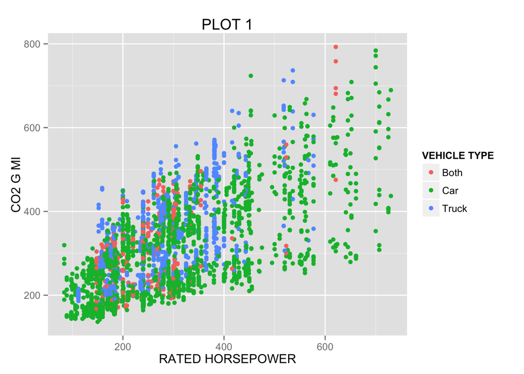

#### Project 4 Bar Chart (R):

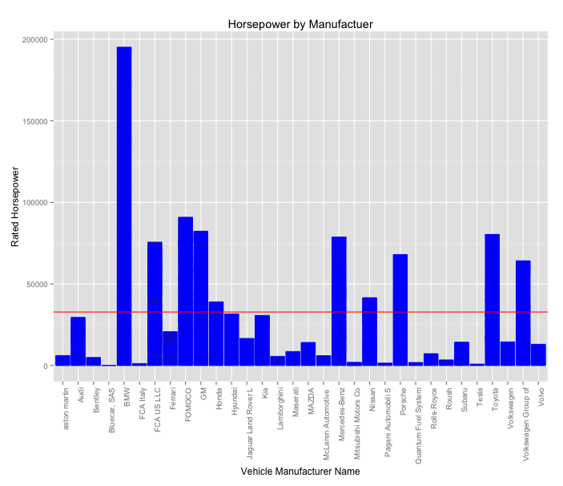

#### Project 4 Cross-Tab (R):

Below is another visualization of a subset of the data. For this visualization, we wanted to observe a cross tab of vehicle types, car makes, and the calculated engine efficiency of the vehicles. Engine efficiency was calculated by dividing the horsepower by the engine displacement, or size of the engine in Liters. Parameters were set for high and low engine efficiency and used to compare all of the vehicles in the cross-tab. This is similar to the visualization made for the previous project in Tableay, but made in R studio.

```r
source("../03 R SQL Visualizations/cross-tab.R", echo = TRUE)
```

```
##
## > require("jsonlite")
##
## > require("RCurl")
##
## > require(ggplot2)
##
## > require(dplyr)
##
## > car <- data.frame(fromJSON(getURL(URLencode(gsub("\n",
## +     " ", "skipper.cs.utexas.edu:5001/rest/native/?query=\"Select VEHICLE_MANUFACTURER_NAME .... [TRUNCATED]
##
## > ggplot() + coord_cartesian() + scale_x_discrete() +
## +     scale_y_discrete() + labs(title = "Crosstab of Data") + labs(x = paste("VEHICLE_TYPE"),
##  .... [TRUNCATED]
```

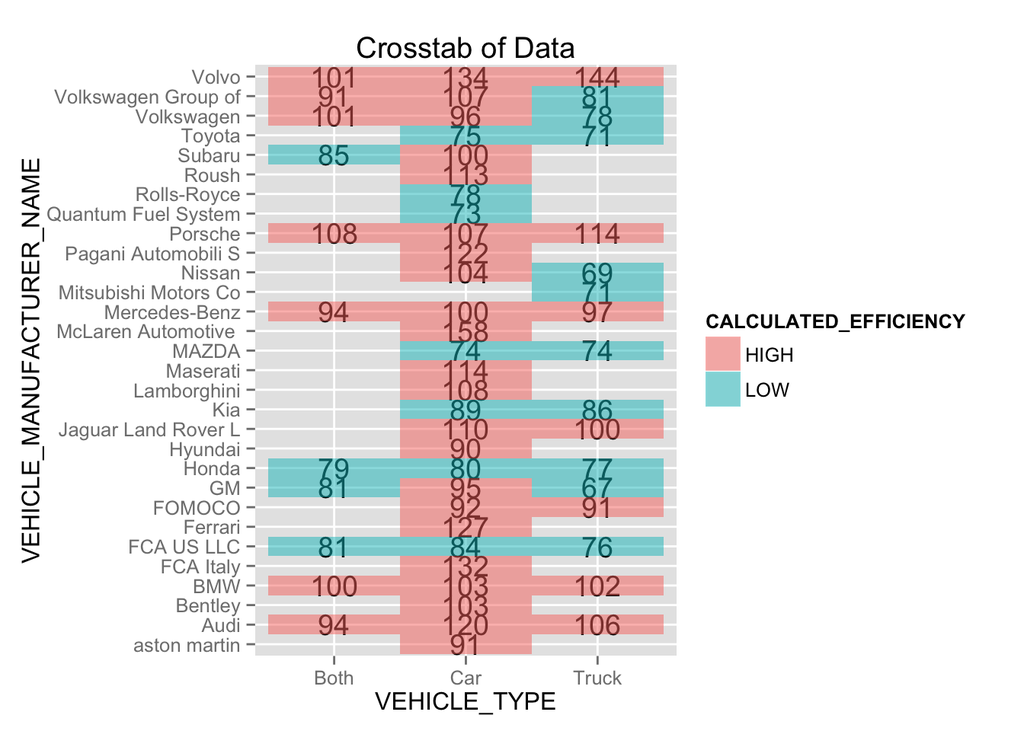